# Recap 2020-04-07

### For comparison - largest spill by volume

```r
most_spilled <- top_n(filter(incidents, commodity != "hvl"), 1, volume)
select(most_spilled, !! relevant_cols)
```

A tibble: 1 × 20

| significant <lgl> | serious <lgl> | incident_ID <dbl> | ID <dbl> | name <chr> | on_offshore <chr> | installation_year <dbl> | cause <chr> | MAP_SUBCAUSE <chr> | fatalities <dbl> | injuries <dbl> | cost_1984 <dbl> | TOTAL_COST_CURRENT <dbl> | commodity <chr> | volume <dbl> | net_loss <dbl> | year <dbl> | date <date> | long <chr> | lat <chr> |
| --- | --- | --- | --- | --- | --- | --- | --- | --- | --- | --- | --- | --- | --- | --- | --- | --- | --- | --- | --- |
| TRUE | TRUE | 19860159 | 15490 | Phillips Pipe Line | onshore | 1939 | all other causes | MISCELLANEOUS | 0 | 26 | 473244.7 | 1010415 | rpp | 55000 | NA | 1986 | 1986-09-03 | NA | NA |

```r
most_spilled$narrative
```

'The floor of tank no. 805 failed spilling unlead motor fuel into the dike system. The area surrounding the terminal was evacuated due to gasoline odor. Productwas recovered using vacuum trucks and a terminal transfer pump. The community returned to their homes within 48 hours. All the product loss was due to evaporation. Insignificant product soaked into the ground.'

**Clearly, volume recovered does not mean the same for these two incidents.**

- In the first incident the oil had to be dug up with the soil
- In the second incident, it could simply be recovered from a dike system

## 3. Findings about progress

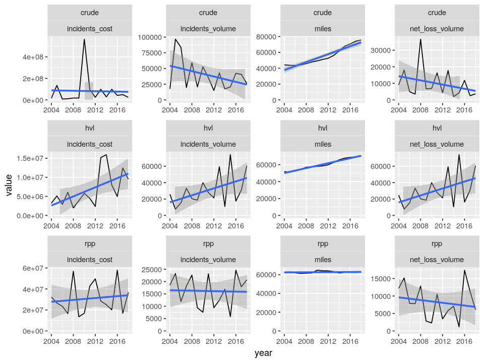

```r
trends
```

**Takeaways**

- Clear downward trends exist only for crude
- For crude, the 2010 incidents did not lead to a change in trajectory

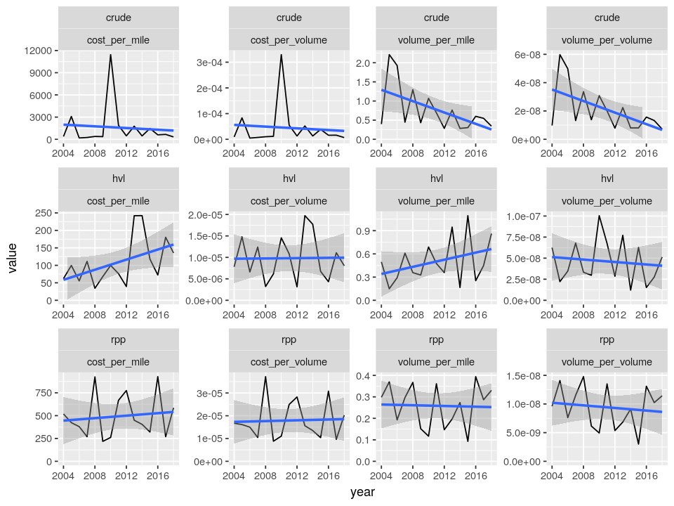

```r
trends_standardized
```

Same as above - learning may only be evident for crude.